# GoodCardio-MaryamShokoufi

## Verify Trends of Fitness across Gender and Miles

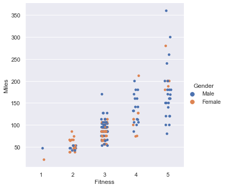

```python
sns.catplot(x='Fitness', y='Miles', hue='Gender', data=data)
plt.show()
```

## Verify Trends of Miles across Usage and Gender

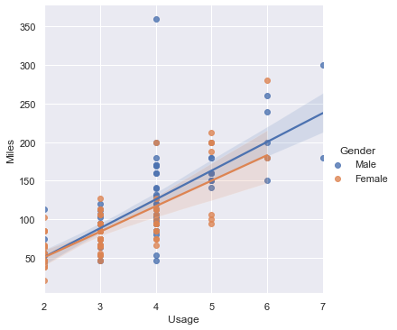

```python
sns.lmplot( x = 'Usage', y = 'Miles', hue = 'Gender', data = data);
```

## Verify Trends of Income across Education and Gender

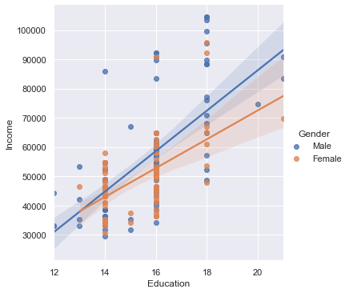

```python
sns.lmplot(x = 'Education', y = 'Income', hue = 'Gender', data = data);
```

## Verify Trends of Income across Age and Product

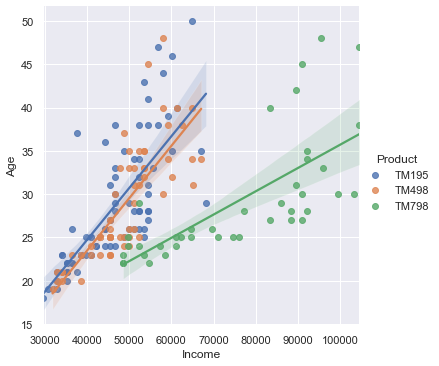

```python
sns.lmplot (x = 'Income', y ='Age', hue = 'Product', data = data);
```

# Insights, Conclusions and Recommendations:

Age, Income and Education level are correlated. Usage, Miles and Fitness are correlated.

Marital Status was not a predictor in product or usage patterns.

Most of customers belong to 20-30 year old age group. Since this is a fitness equipment, there is a lot of potential to gain customers from other age groups. Might need to change advertisement method to target and reach other age groups.

Data shows that Products TM195 and TM498 seem to apeal to both genders since they have similar number of customers, but product TM798 has much fewer female customers (33 Males to 7 Females). Since this product is also correlates to customers that have rated themselves with a higher Fitness level, maybe the marketing approach is turning away potential amature customers by advertising for professionals only. Data also suggests that customers that want to run more Miles, and predicted higher number of weekly Usage, are more likely to buy TM798.

Higher Income correlates to age, higher Education, and increases the likelihood of a customer buying TM798.

The Fitness measure was provided by customers and is not a great measure. Contrary to what we would expect, shows that customers in age group 40-50 have rated themselves with highest average Fitness rating. There's a difference between Males and Females in that Females have reported lower Fitness ratings in total across all age groups.